# Planos de Negócio e Instrumentos de Fomento Regional

Empreendedorismo Tecnológico e Desenvolvimento Territorial · Aula 10

Prof. Dr. Luiz Diego Vidal Santos

## Unidade II Visão Geral da Aula

Roteiro da aula · 4 horas Tópicos estruturantes

1. Modelo de Negócio vs. Plano de Negócio: quando usar cada um?
2. Estrutura completa de um Plano de Negócio Tecnológico.
3. Fontes de financiamento: *bootstrapping*, subvenção e *venture capital*.
4. Fundos regionais de desenvolvimento (FNE/BNB, FINEP, FAPs).
5. *Pitch deck* e comunicação para bancas de fomento e investidores.

Objetivo central Planejamento e captação regional

Capacitar o(a) discente a estruturar **planos de negócio** para empreendimentos tecnológicos e projetos territoriais, conectando a lógica estratégica e operacional às **fontes de financiamento e fomento regional** disponíveis no Brasil.

**Ponte prática:** traduzir hipóteses validadas no *Canvas* em projetos financiáveis por editais e bancos regionais.

# Plano de Negócio na Era Ágil

## Conceito Para que serve o Plano de Negócio hoje?

Canvas → Plano Complementaridade com o Canvas

- O **Canvas** e o *Lean Startup* servem para **buscar e validar** o modelo de negócio sob alta incerteza.
- O **Plano de Negócio** entra quando é necessário **executar, escalar e captar recursos formais** (bancos de desenvolvimento, editais FINEP/FAPs, investidores institucionais).
- **Função dupla:** alinhamento interno da equipe e **redução de assimetria de informação** perante financiadores.

Arquitetura documental Estrutura padrão de um plano tecnológico

1. **Sumário Executivo** (síntese decisiva em 1–2 páginas);
2. **Análise de Mercado e Setorial** (TAM/SAM/SOM, 5 Forças, diferenciais);
3. **Solução Tecnológica e PI** (TRL, proteção, *roadmap* de P&D);
4. **Plano Operacional e Locacional** (fornecedores, equipe, infraestrutura);
5. **Plano de Marketing e Vendas** (CAC, LTV, canais, precificação);
6. **Plano Financeiro** (investimentos, DRE projetada, fluxo de caixa, *break-even*).

# Financiamento e Fomento Regional

## Território A Escada do Capital e o Fomento no Nordeste

| Estágio | Fontes Típicas | Natureza do Capital |
| --- | --- | --- |
| **Ideação / P&D** | *Bootstrapping*, editais **PIPE/FAPs, Centelha, Tecnova** | Não reembolsável (subvenção) |
| **Validação / Tração** | Investidor-anjo, aceleradoras, **FINEP Startup** | *Equity* / mútuo conversível |
| **Escala Regional** | Fundos de *Seed / Venture Capital*, **FNE Inovação (BNB)**, BNDES | *Equity* ou dívida subsidiada |

Política regional Instrumentos territoriais no Nordeste

- **FNE (Fundo Constitucional de Financiamento do Nordeste — BNB):** linhas com juros diferenciados para inovação, sustentabilidade e infraestrutura produtiva regional.
- **SUDENE / Incentivos Fiscais:** redução de IRPJ para empreendimentos prioritários na área de atuação.
- **FAPESB / FINEP:** fomento direto a *spin-offs* e cooperação ICT–Empresa.

No Nordeste, instrumentos constitucionais (FNE/BNB) e subvenções (FINEP/FAPs) compensam parcialmente a menor densidade de *venture capital* privado.

## Síntese Esquema: Escada de Financiamento e Fomento Regional

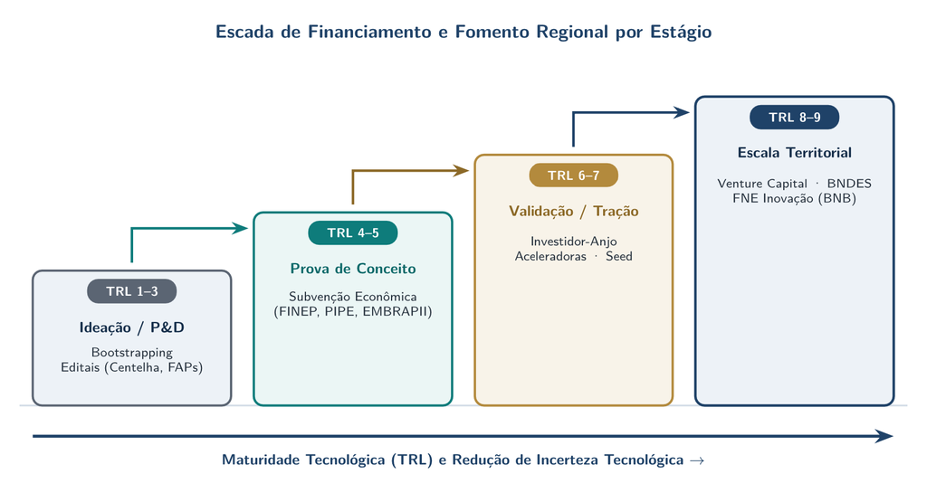

Instrumentos financeiros por estágio de maturidade tecnológica (TRL): do bootstrapping e subvenção econômica (FINEP/FAPs) ao Venture Capital e FNE Inovação.

Escada de Financiamento e Fomento Regional por estágio TRL Alinhamento entre redução de incerteza tecnológica e adequação das fontes de capital

Captar a fonte errada no estágio errado (ex.: dívida bancária em TRL 2) compromete a sobrevivência financeira do empreendimento.

# Métricas-Chave e Pitch

## Método Indicadores de Tração, Pitch Deck e Leituras

Economia da unidade *Unit Economics* essenciais

- **CAC (Custo de Aquisição de Cliente):** gasto comercial e de marketing dividido por novos clientes.
- **LTV (*Lifetime Value*):** margem líquida gerada pelo cliente ao longo do relacionamento.
- **Ponto de Equilíbrio (*Break-even*):** volume mínimo de vendas para cobrir custos fixos e variáveis.

**Regra de saúde financeira:** $\text{LTV} / \text{CAC} \ge 3$ com recuperação do CAC em até 12 meses.

Preparação · Aula 11 Leituras para a próxima aula

- **CHESBROUGH, H.** *Open innovation* (Caps. 1 e 3).
- **KURATKO, D. F.; COVIN, J. G.** *Corporate entrepreneurship*.
- Literatura sobre **Spin-offs Acadêmicas** e atuação dos **NITs** no Brasil.